# Exploring Data with Visuals

# Exploring the Video Games Dataset with Visuals

We started exploring the Video Games Dataset from Kaggle already, now let’s add some analysis with visuals to get a better idea of what is going on with the data.

# Box and Whisker Plots

These are a good way of visualising the median and first to third quartiles of our data. From the given dataset, we can see that the scores given to games lend themselves to a boxplot. Not too surprisingly, we can see that users (ie. game players) tend to be a little more generous in their scoring than critics are, which is probably why they are called critics.

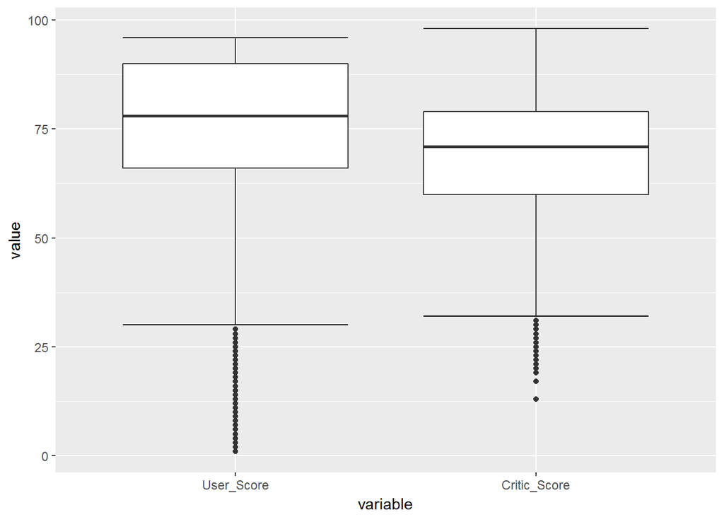

```r
scores = games %>% select(User_Score, Critic_Score)
scores$User_Score = as.numeric(scores$User_Score)
scores$Critic_Score = as.numeric(scores$Critic_Score)
scores = melt(scores, measure.vars = c("User_Score", "Critic_Score"), na.rm = TRUE) #melt to get variables right for boxplot
g = ggplot(scores, aes(variable, value))
g = g + stat_boxplot(geom = "errorbar") #add whiskers
g = g + geom_boxplot()  #add boxplot
g
```

## Histogram

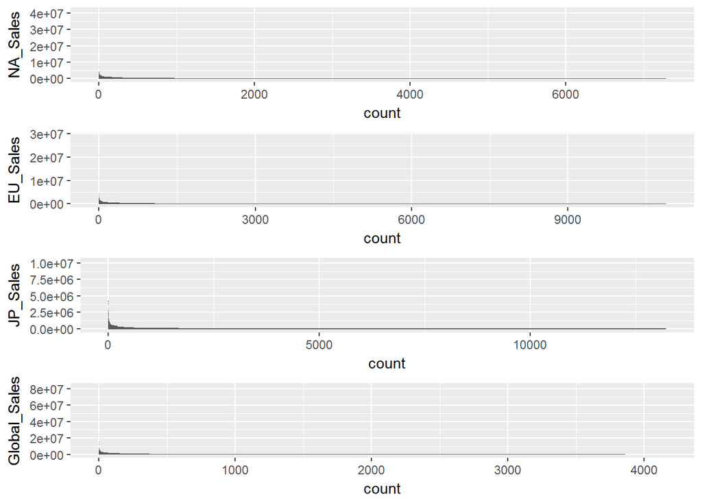

```r
gNA = ggplot(games, aes(NA_Sales)) + geom_histogram(binwidth = 100000) + coord_flip()
gEU = ggplot(games, aes(EU_Sales)) + geom_histogram(binwidth = 100000) + coord_flip()
gJP = ggplot(games, aes(JP_Sales)) + geom_histogram(binwidth = 100000) + coord_flip()
gOther = ggplot(games, aes(Global_Sales)) + geom_histogram(binwidth = 100000) + coord_flip()
grid.arrange(gNA, gEU, gJP, gOther, ncol = 1)
```

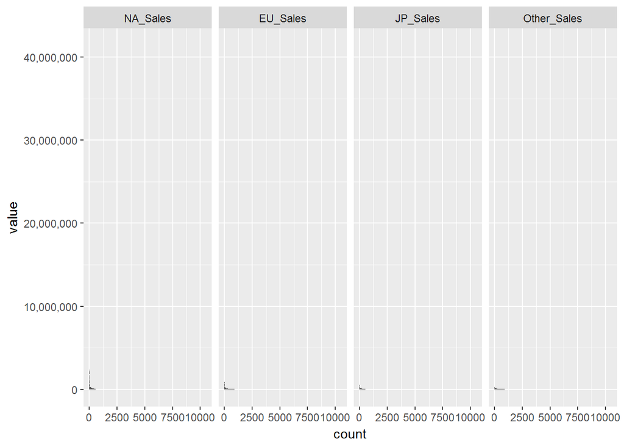

```r
rm(gNA, gEU, gJP, gOther) #always keep your workspace tidy

#same plot, but using ggplot entirely
scores = games %>% select(NA_Sales, EU_Sales, JP_Sales, Other_Sales) %>% melt()
g = ggplot(scores, aes(value))
g = g + geom_bar()
g = g + facet_grid(. ~ variable)
g = g + coord_flip()
g = g + scale_x_continuous(labels = comma)
g
```

```r
sales = games %>% filter(NA_Sales > 1000000 | EU_Sales > 1000000 | JP_Sales > 1000000 | Other_Sales > 1000000)%>% select(NA_Sales, EU_Sales, JP_Sales, Other_Sales) %>% melt()
```

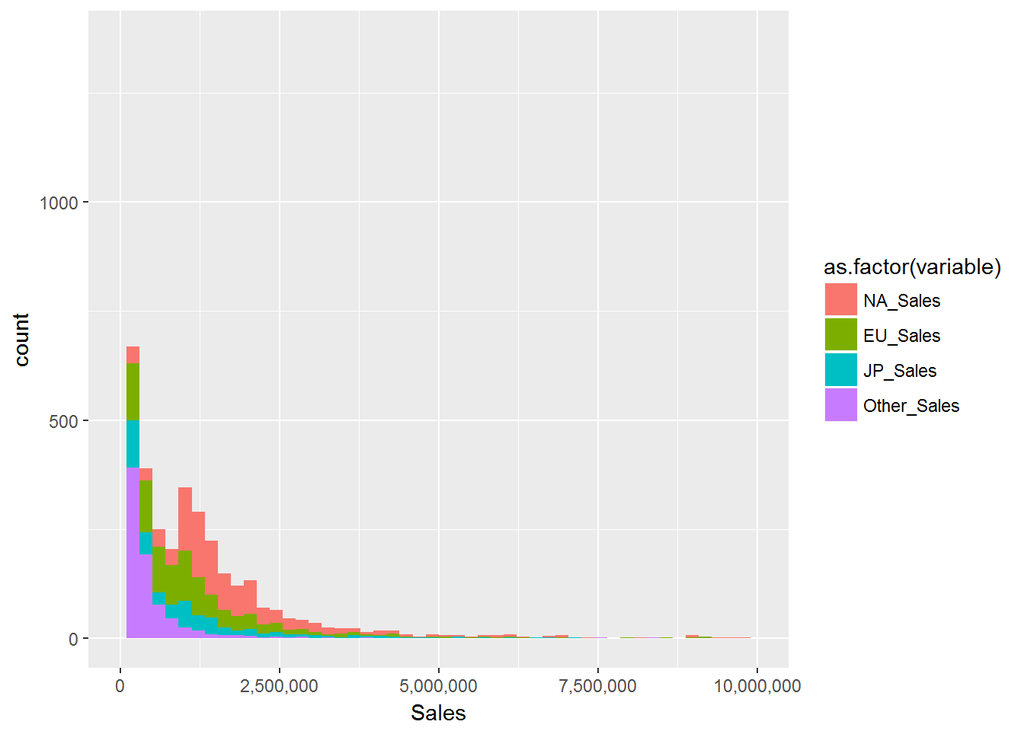

```r
g = ggplot(sales, aes(value, fill=as.factor(variable)))
g = g + geom_histogram(bins = 50)
g = g + xlab("Sales")
g = g + scale_x_continuous(labels = comma, limits = c(0, 10000000))
g
```

Now, let’s take a look at total sales by region to see where we can expect to sell the most games. This will not give us anything really interesting as game sales rely on many more factors, but it could tell us where to aim our next game we want to deliver. As we would expect, the North America region makes up the single biggest market, making up nearly half of global sales

```r
sales = games %>% select(NA_Sales, EU_Sales, JP_Sales, Other_Sales, Global_Sales) %>% summarise_each(funs(sum)) %>% melt()
```

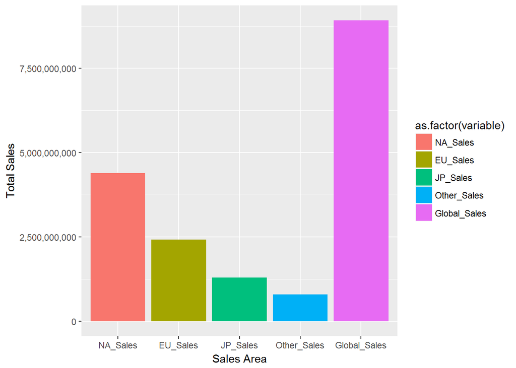

```r
g = ggplot(sales, aes(x = variable, y = value, fill = as.factor(variable)))
g = g + geom_bar(stat = "identity")
g = g + scale_y_continuous(labels = comma)
g = g + xlab("Sales Area")
g = g + ylab("Total Sales")
g
```

```r
#plot a pie chart, just out of interest
sales = games %>% select(NA_Sales, EU_Sales, JP_Sales, Other_Sales) %>% summarise_each(funs(sum)) %>% melt()
g = ggplot(sales, aes(y = value, fill=as.factor(variable)))
# to-do: get this to work
```

Similarly to what we have already done, let’s see what the top platforms are. We can see that the top platforms are the PS2, DS, PS3, Wii and X360.

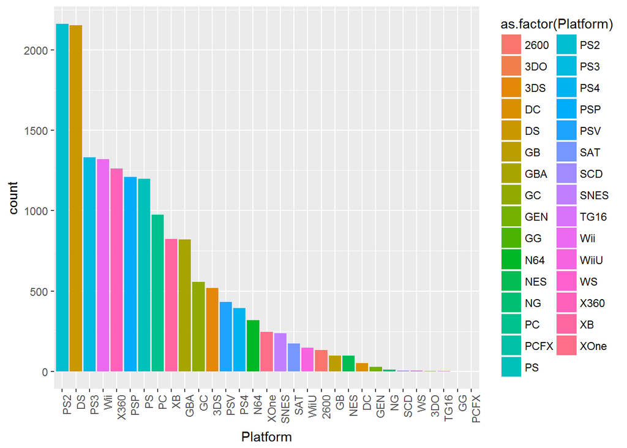

```r
platforms = games %>% select(Platform)
g = ggplot(platforms, aes(x=reorder(Platform, Platform, function(x) - length(x)), fill=as.factor(Platform))) #reorder the bars for largest to smallest
g = g + geom_bar()
g = g + theme(axis.text.x=element_text(angle = 90, hjust = 1))
g = g + xlab("Platform")
g
```

## Correlations

We can start looking at correlations in the data. Let’s look at the correlation between Critic Scores and User Scores. We would expect these to be well correlated although as we saw earlier, the User Scores were typically higher than the Critics’. We also want to look at the correlation between scores and total sales.

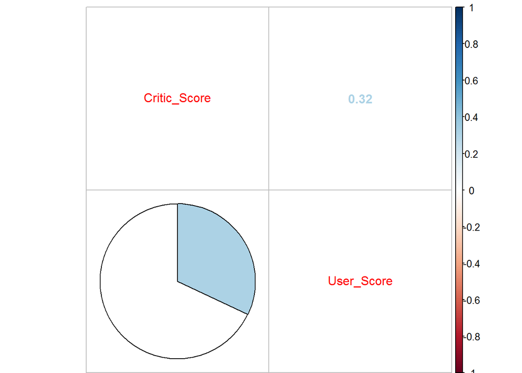

```r
corrScore = games %>% select(Critic_Score, User_Score)
corrScore = corrScore[complete.cases(corrScore), ] #remove missing scores
corrScore$User_Score = as.numeric(corrScore$User_Score)
corrplot.mixed(cor(corrScore),lower = "pie", upper = "number") #there are tons of other ways to plot this
```

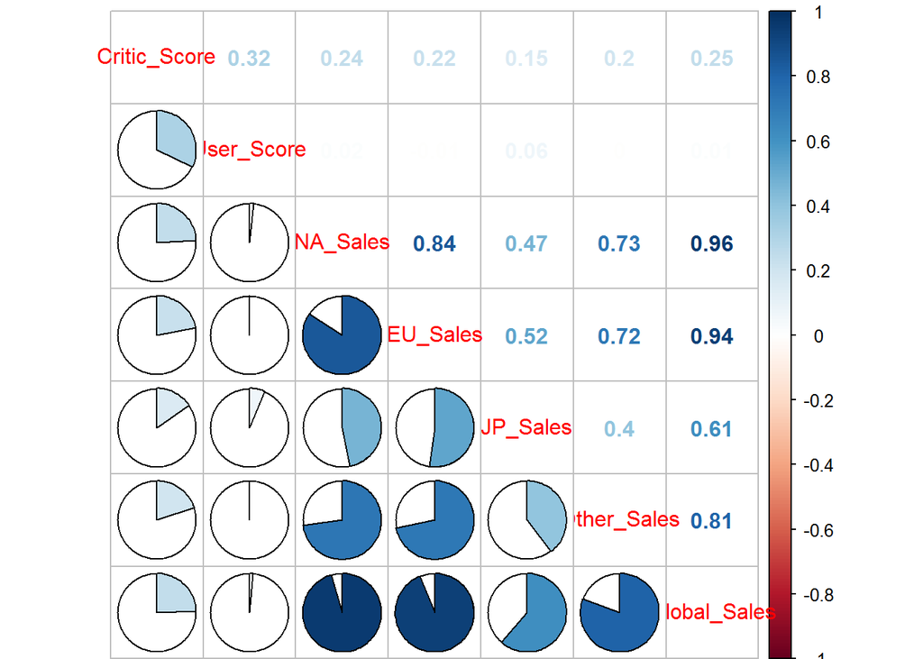

```r
corrSales = games %>% select(Critic_Score, User_Score, NA_Sales, EU_Sales, JP_Sales, Other_Sales, Global_Sales)
corrSales$User_Score = as.numeric(corrSales$User_Score)
corrSales = corrSales[complete.cases(corrSales), ] #remove missing data
corrplot.mixed(cor(corrSales), lower = "pie", upper = "number")
```

Interestingly, we can see here that Critic Score only correlates fairly lowly with actual sales. It is important to see that North America and European sales correlate quite closely, which implies that both markets like the same types of games.

## Scatterplot

Let’s take a look at how games development and releases have gone over the years. for the top 5 platforms.

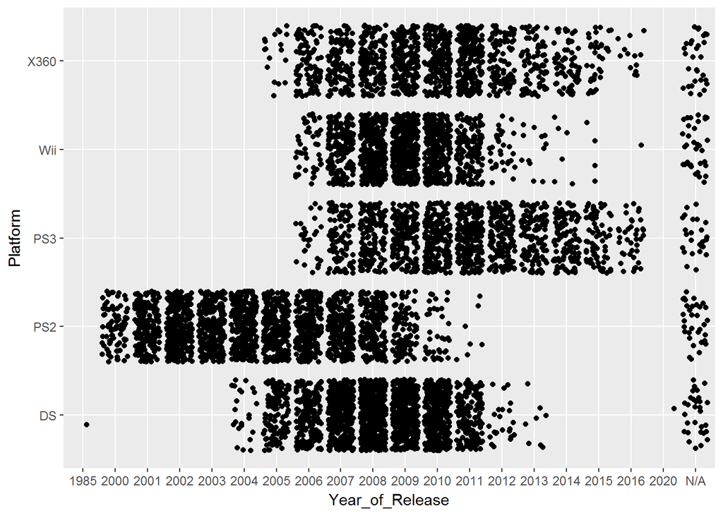

```r
development = games %>% select(Platform, Year_of_Release) %>% filter(Platform == "PS2" | Platform == "DS" | Platform == "PS3" | Platform == "Wii" | Platform == "X360")
g = ggplot(development, aes(x = Year_of_Release, y = Platform))
g = g + geom_jitter()
g
```